# Backcalculating Reporting Delays Distributions from Linelist Data

This R Markdown document walks through the steps for imputing a reporting delay distribution from linelist data with missing disease onset data, adapted in STAN from [Li and White](https://journals.plos.org/ploscompbiol/article?id=10.1371/journal.pcbi.1009210)

There are two starting points for this vignette: either you have **caseCount** data, which are aggregated case counts by day, or you have **Line-list data** means you have a single row for each case, that has dates for: infection, symptom onset, positive test, and when this was reported to public health agencies.

### Example: lineList data

```r
library(WhiteLabRt)
```

**Step 1.** Load data

```r
data("sample_report_dates")
data("sample_onset_dates")
```

**Step 2.** Creating `linelist` object

```r
my_linelist <- create_linelist(report_dates = sample_report_dates,
                                onset_dates = sample_onset_dates)
head(my_linelist)
```

```
#>   report_date delay_int onset_date is_weekend report_int week_int
#> 1  2020-01-01         4 2019-12-28          0          1        1
#> 2  2020-01-01         4 2019-12-28          0          1        1
#> 3  2020-01-01        NA       <NA>          0          1        1
#> 4  2020-01-01        NA       <NA>          0          1        1
#> 5  2020-01-01        NA       <NA>          0          1        1
#> 6  2020-01-01         8 2019-12-24          0          1        1
```

**Step 3.** Define the serial interval. The `si()` function creates a vector of length 14 with shape and rate for a gamma distribution. Note, this **has** a leading 0 to indicate no infections on the day of disease onset.

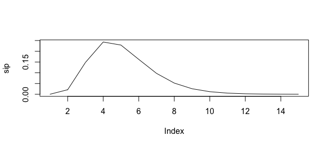

```r
sip <- si(14, 4.29, 1.18)
plot(sip, type = 'l')
```

**Step 5.** Run the back-calculation algorithm. The default is an R(t) sliding window of 7 days. Additional options to STAN can be specified in the last argument (e.g., chains, cores, control).

```r
out_list_demo <- run_backnow(my_linelist, sip = sip, chains = 1)
```

**Plot outputs**. The points are aggregated reported cases, and the red line (and shaded confidence interval) represent the back-calculated case onsets that lead to the reported data.

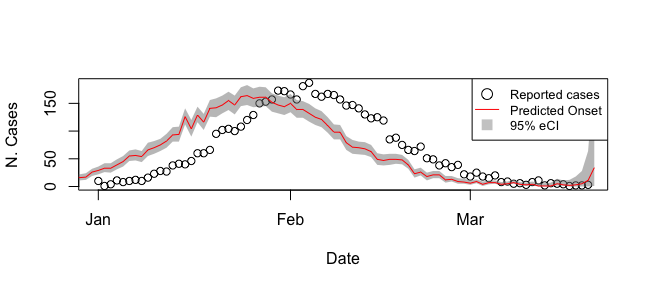

```r
data("out_list_demo")
plot(out_list_demo, "est")
```

You can also plot the `R(t)` curve over time. In this case, the red line (and shaded confidence interval) represent the time-varying r(t). See Li and White for description.

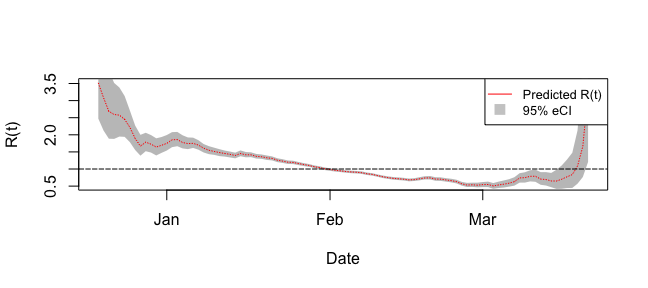

```r
data("out_list_demo")
plot(out_list_demo, "rt")
```

### Example: Case Count data

You can also do the same from case count data, although at some point you will have to assume a reporting delay distribution, so this would be a little circular.

**Step 1.** Load data

```r
data("sample_dates")
data("sample_location")
data("sample_cases")

head(sample_dates)
```

```
#> [1] "2020-01-01" "2020-01-02" "2020-01-03" "2020-01-04" "2020-01-05"
#> [6] "2020-01-06"
```

```r
head(sample_cases)
```

```
#> [1] 10  1  4 11  8 10
```

```r
head(sample_location)
```

```
#> [1] "Tatooine" "Tatooine" "Tatooine" "Tatooine" "Tatooine" "Tatooine"
```

**Step 2.** Creating case-counts

```r
caseCounts <- create_caseCounts(date_vec = sample_dates,
                                location_vec = sample_location,
                                cases_vec = sample_cases)
head(caseCounts)
```

```
#>         date cases location
#> 1 2020-01-01    10 Tatooine
#> 2 2020-01-02     1 Tatooine
#> 3 2020-01-03     4 Tatooine
#> 4 2020-01-04    11 Tatooine
#> 5 2020-01-05     8 Tatooine
#> 6 2020-01-06    10 Tatooine
```

**Step 3.** Convert to linelist data. You can specify the distribution for `my_linelist` in `convert_to_linelist`. `reportF` is the distribution function, `_args` lists the distribution params that are not `x`, and `_missP` is the percent missing. This must be between ${0 < x < 1}$. Both ‘caseCounts’ and ‘caseCounts_line’ objects can be fed into `run_backnow`. The implied onset distribution is `rnbinom()` with `size = 3` and `mu = 9`, with `reportF_missP = 0.6` .

```r
my_linelist <- convert_to_linelist(caseCounts,
                                   reportF = rnbinom,
                                   reportF_args = list(size = 3, mu = 9),
                                   reportF_missP = 0.6)
head(my_linelist)
```

```
#>   report_date delay_int onset_date is_weekend report_int week_int
#> 1  2020-01-01        NA       <NA>          0          1        1
#> 2  2020-01-01        12 2019-12-20          0          1        1
#> 3  2020-01-01        NA       <NA>          0          1        1
#> 4  2020-01-01        NA       <NA>          0          1        1
#> 5  2020-01-01         5 2019-12-27          0          1        1
#> 6  2020-01-01        NA       <NA>          0          1        1
```

**Step 4.** Define the serial interval. The `si()` function creates a vector of length 14 with alpha and beta as defined in Li and White, for COVID-19.

```r
sip <- si(14, 4.29, 1.18)
```

**Step 5.** Run the back-calculation algorithm. The defaults are 2000 iterations and an R(t) sliding window of 7 days.

```r
options(mc.cores = 4)

out_list_demo <- run_backnow(my_linelist, sip = sip)
```